# Course Project -1

Chandana

6 June 2018

## To analyse personal movement data

It is now possible to collect a large amount of data about personal movement using activity monitoring devices such as a Fitbit, Nike Fuelband, or Jawbone Up. These type of devices are part of the “quantified self” movement - a group of enthusiasts who take measurements about themselves regularly to improve their health, to find patterns in their behavior, or because they are tech geeks. But these data remain under-utilized both because the raw data are hard to obtain and there is a lack of statistical methods and software for processing and interpreting the data.

```r
activity<-read.csv("activity.csv")
head(activity)
```

```
##   steps       date interval
## 1    NA 2012-10-01        0
## 2    NA 2012-10-01        5
## 3    NA 2012-10-01       10
## 4    NA 2012-10-01       15
## 5    NA 2012-10-01       20
## 6    NA 2012-10-01       25
```

```r
summary(activity$steps)
```

```
##    Min. 1st Qu.  Median    Mean 3rd Qu.    Max.    NA's
##    0.00    0.00    0.00   37.38   12.00  806.00    2304
```

```r
activity$date<-as.Date(activity$date,"%Y-%m-%d")
```

## Total steps every day

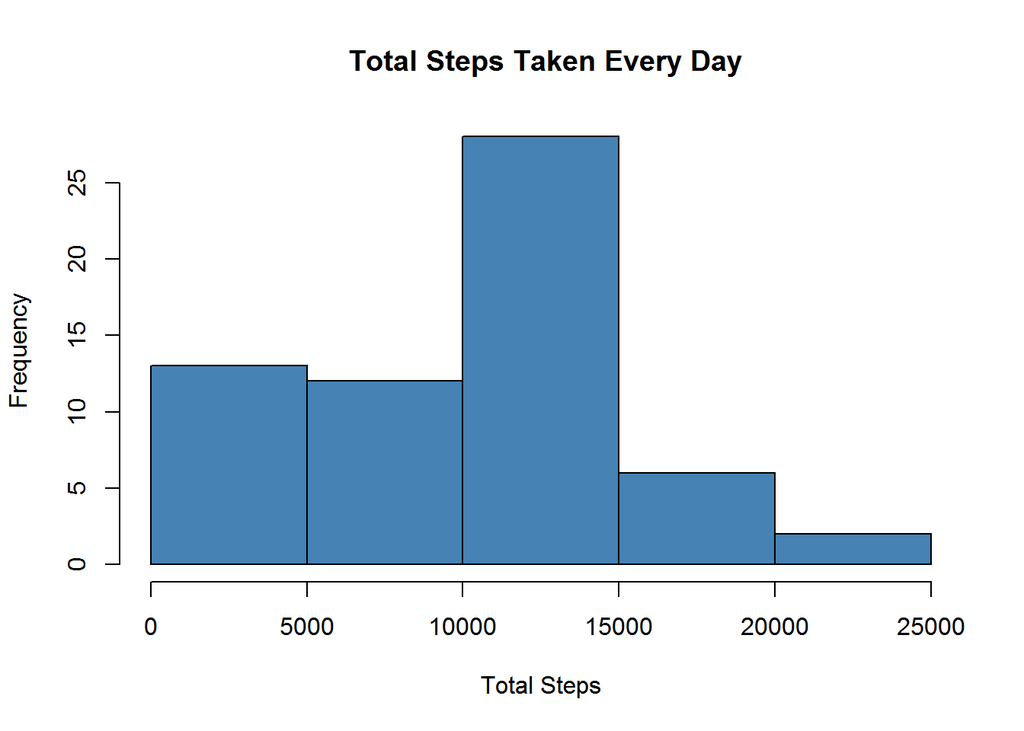

```r
steps<-with(activity,tapply(steps,date,sum, na.rm=T))
hist(steps, xlab= "Total Steps", main= " Total Steps Taken Every Day", col= "steel blue")
```

```r
mean0<-round(mean(steps))
median0<-median(steps)
```

The median of total steps taken in a day is 10395, mean is 9354.

## Variation observed in different intervals

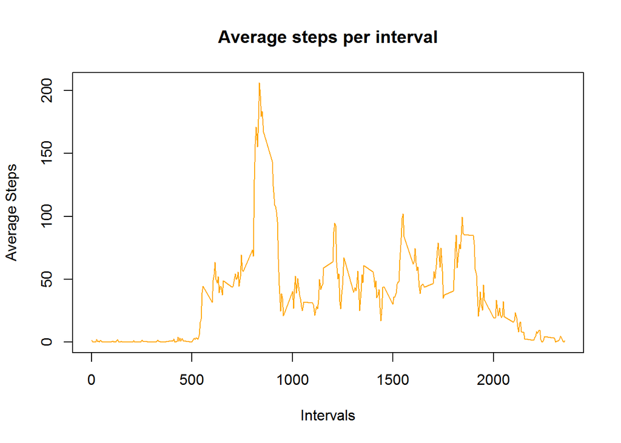

```r
intervalsteps<-aggregate(steps~interval, activity, FUN = mean)
plot(intervalsteps$interval, intervalsteps$steps, type="l", xlab= "Intervals",ylab="Average Steps",main="Average steps per interval",col="orange")
```

```r
max<-subset(intervalsteps, intervalsteps$steps==max(intervalsteps$steps))
maximum<-max$steps
maxinterval<- max$interval
```

The interval with maximum number of steps is 835.

```r
nNA<-sum(is.na(activity$steps))
```

The number of NAs in the data set is 2304.

### To impute NAs by sustituting with average steps taken in the interval

```r
toclean<-merge(activity,intervalsteps, by= "interval")
toclean<-toclean[order(toclean$date),]
names(toclean)<-c("interval", "steps", "date","meanin" )
i<-0
while(i<nrow(toclean)){
  i<-i+1
  if(is.na(toclean$steps[i])){
    toclean$steps[i]<-toclean$meanin[i]
  }
}
activityclean<-toclean
rm(toclean)
```

## Total steps every day for imputed dataset

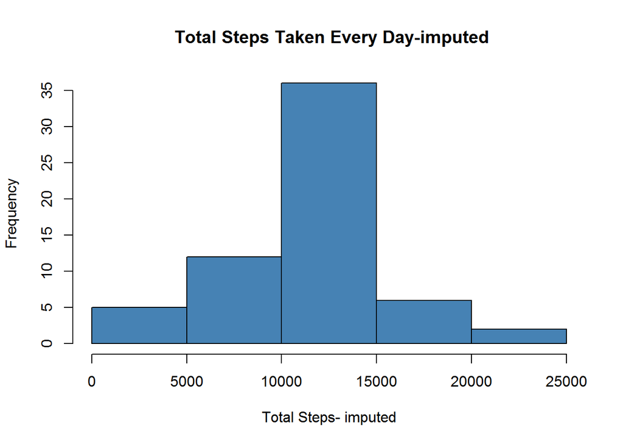

```r
steps2<-with(activityclean,tapply(steps,date,sum, na.rm=T))
hist(steps2, xlab= "Total Steps- imputed", main= " Total Steps Taken Every Day-imputed", col= "steel blue")
```

```r
mean2<-round(mean(steps))
median2<-median(steps)
changemean<-((mean2-mean0)/mean0)*100
changemedian<-((median2-median0)/median0)*100
```

[figure not shown]

```r
activityclean$day<-strftime(activityclean$date, "%A")
i<-0
while(i<nrow(activityclean)){
  i<-i+1
  if(activityclean$day[i] =="Monday"){
    activityclean$type[i]<-"Weekday"
  }
  if(activityclean$day[i] =="Tuesday"){
    activityclean$type[i]<-"Weekday"
  }
  if(activityclean$day[i] =="Wednesday"){
    activityclean$type[i]<-"Weekday"
  }
  if(activityclean$day[i] =="Thursday"){
    activityclean$type[i] <-"Weekday"
  }
  if(activityclean$day[i] =="Friday"){
    activityclean$type[i]<-"Weekday"
  }
  else{
    activityclean$type[i] <- "Weekend"
  }
}
weekday<-subset(activityclean,activityclean$type == "Weekday")
weekend<-subset(activityclean,activityclean$type == "Weekend")
weekdayaverage<-aggregate(steps~interval, weekday, FUN = mean)
weekendaverage<-aggregate(steps~interval, weekend, FUN = mean)
par(mfrow=c(2,1))
with(weekdayaverage,plot(interval,steps,xlab = "Interval",type="l",col="orange", main =   "Average for weekdays", ylab = "Average Steps"))
with(weekendaverage,plot(interval,steps,xlab = "Interval",type="l",col="orange",main = "Average for weekends", ylab= "Average Steps"))
```